# Final project

```r
# loading the fertility data set
fertility_data <- wb_data(country = "countries_only",
                           indicator = "SP.DYN.TFRT.IN",
                           start_date = 1960,
                           end_date = 2021,
                           return_wide = FALSE)

# loading the life expectancy data set
life_expectancy_data <- wb_data(country = "countries_only",
                                indicator = "SP.DYN.LE00.IN",
                                start_date = 1960,
                                end_date = 2021,
                                return_wide = FALSE)

# loading the GDP per capita data set
gdp_data <- wb_data(country = "countries_only",
                                indicator = "NY.GDP.PCAP.CD",
                                start_date = 1960,
                                end_date = 2021,
                                return_wide = FALSE)
```

```r
# Join fertility data set and life expectancy data set
result <- full_join(fertility_data, life_expectancy_data, by = c("country" = "country", "date" = "date"))

# Join the result with GDP per capita data set
final_join <- full_join(result, gdp_data, by = c("country" = "country", "date" = "date"))

df <- final_join %>%
  select(country, iso3c, date, indicator.x, value.x, indicator.y, value.y, indicator, value)
```

```r
# Renaming a column
df <- df %>% rename(fertility_rate = indicator.x)
df <- df %>% rename(life_expectancy_at_birth = indicator.y)
df <- df %>% rename(gdp_per_capita_USD  = indicator)

# Moving values from one column to another
df$fertility_rate <- df$value.x
df$life_expectancy_at_birth <- df$value.y
df$gdp_per_capita_USD <- df$value

# Selecting useful columns
df <- df %>%
  select(country, iso3c, date, fertility_rate, life_expectancy_at_birth, gdp_per_capita_USD)

df
```

```
## # A tibble: 13,454 × 6
##    country  iso3c  date fertility_rate life_expectancy_at_b…¹ gdp_per_capita_USD
##    <chr>    <chr> <dbl>          <dbl>                  <dbl>              <dbl>
##  1 Afghani… AFG    2021           4.64                   62.0               364.
##  2 Afghani… AFG    2020           4.75                   62.6               517.
##  3 Afghani… AFG    2019           4.87                   63.6               501.
##  4 Afghani… AFG    2018           5.00                   63.1               502.
##  5 Afghani… AFG    2017           5.13                   63.0               530.
##  6 Afghani… AFG    2016           5.26                   63.1               520.
##  7 Afghani… AFG    2015           5.40                   62.7               592.
##  8 Afghani… AFG    2014           5.56                   62.5               628.
##  9 Afghani… AFG    2013           5.70                   62.4               652.
## 10 Afghani… AFG    2012           5.83                   61.9               663.
## # ℹ 13,444 more rows
## # ℹ abbreviated name: ¹life_expectancy_at_birth
```

## Global Fertility Rate Trends and Dynamics: Analyzing Key Countries

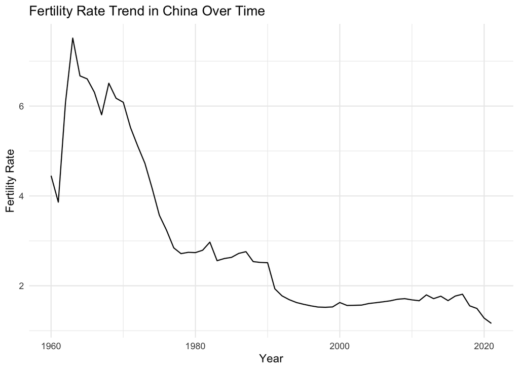

```r
# China
china_data <- df %>% filter(country == "China")

ggplot(china_data, aes(x = date, y = fertility_rate)) +
  geom_line() +
  labs(title = "Fertility Rate Trend in China Over Time",
       x = "Year",
       y = "Fertility Rate") +
  theme_minimal()
```

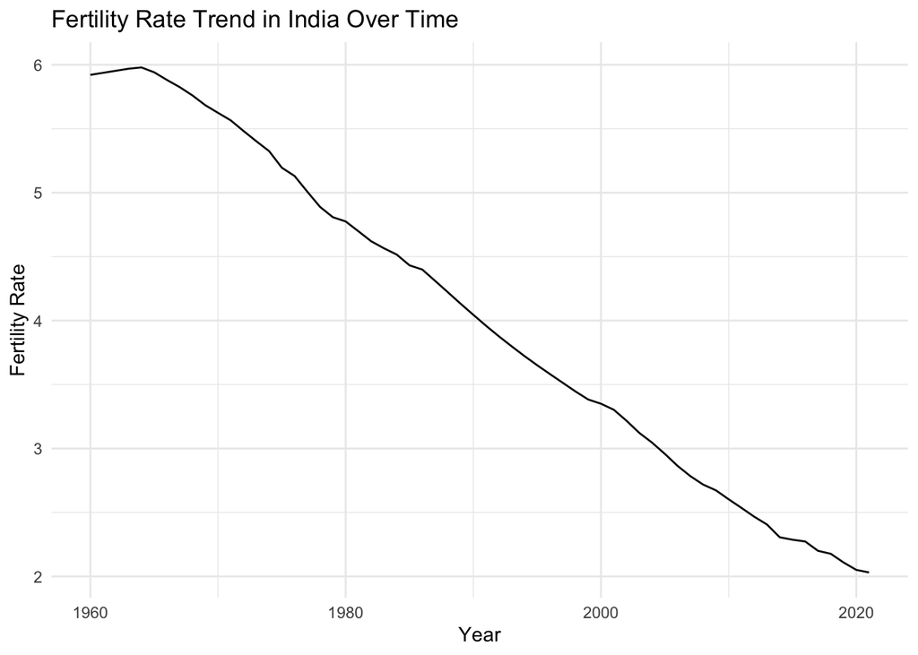

```r
# India
india_data <- df %>% filter(country == "India")

ggplot(india_data, aes(x = date, y = fertility_rate)) +
  geom_line() +
  labs(title = "Fertility Rate Trend in India Over Time",
       x = "Year",
       y = "Fertility Rate") +
  theme_minimal()
```

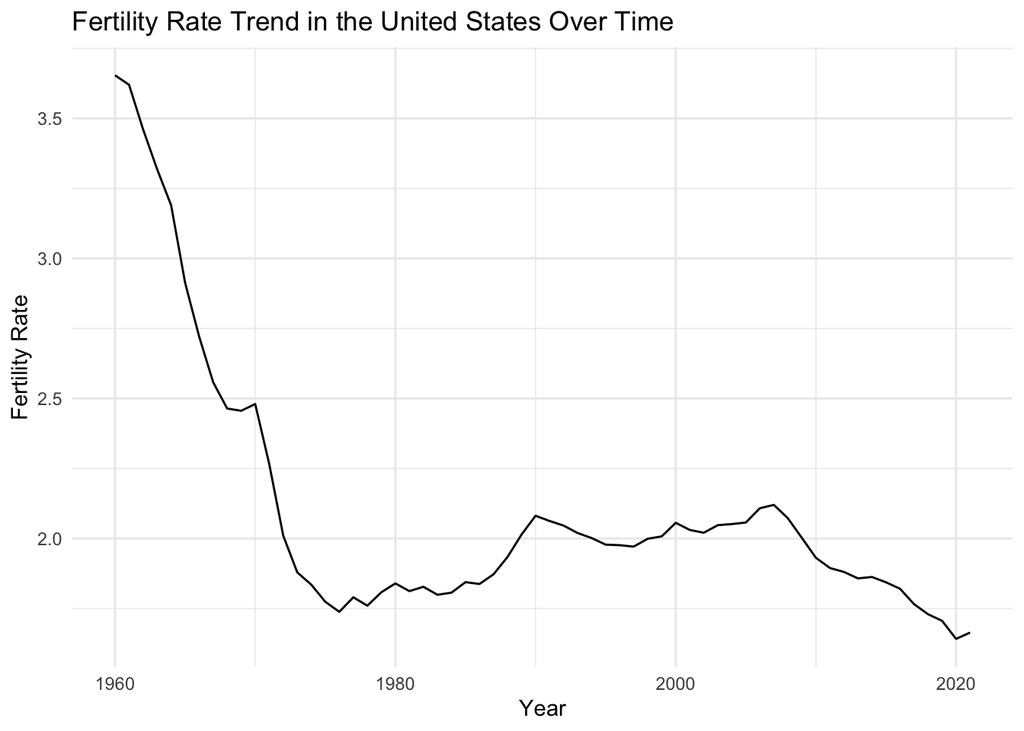

```r
# United States
US_data <- df %>% filter(country == "United States")

ggplot(US_data, aes(x = date, y = fertility_rate)) +
  geom_line() +
  labs(title = "Fertility Rate Trend in the United States Over Time",
       x = "Year",
       y = "Fertility Rate") +
  theme_minimal()
```

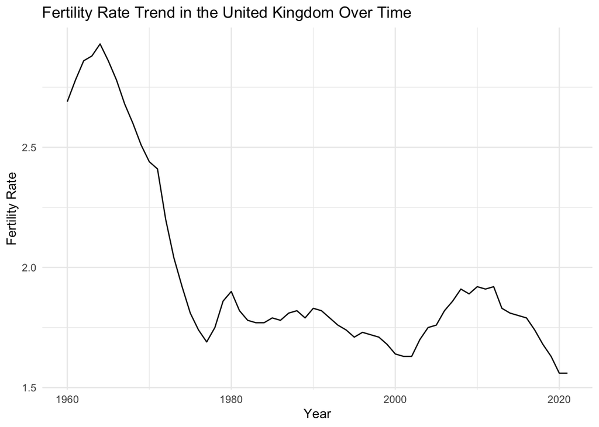

```r
# United Kingdom
UK_data <- df %>% filter(country == "United Kingdom")

ggplot(UK_data, aes(x = date, y = fertility_rate)) +
  geom_line() +
  labs(title = "Fertility Rate Trend in the United Kingdom Over Time",
       x = "Year",
       y = "Fertility Rate") +
  theme_minimal()
```

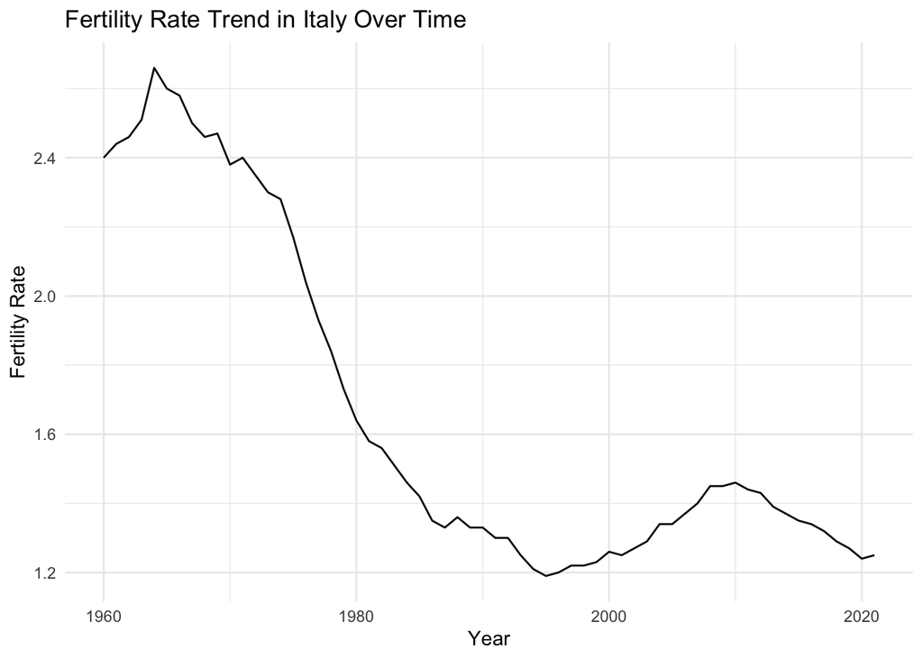

```r
# Italy
italy_data <- df %>% filter(country == "Italy")

ggplot(italy_data, aes(x = date, y = fertility_rate)) +
  geom_line() +
  labs(title = "Fertility Rate Trend in Italy Over Time",
       x = "Year",
       y = "Fertility Rate") +
  theme_minimal()
```

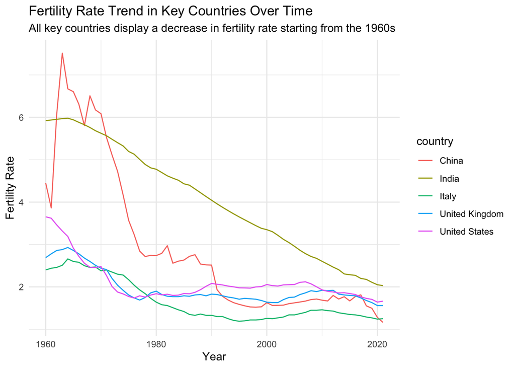

```r
countries <- c("China", "India", "United States", "United Kingdom", "Italy")

# Filter data for these countries
key_countries_data <- df %>% filter(country %in% countries)

ggplot(key_countries_data, aes(x = date, y = fertility_rate, color = country)) +
  geom_line() +
  labs(title = "Fertility Rate Trend in Key Countries Over Time",
       subtitle = "All key countries display a decrease in fertility rate starting from the 1960s",
       x = "Year",
       y = "Fertility Rate") +
  theme_minimal()
```

The relationship between a country’s urbanization/development and its fertility rate is multifaceted, often characterized by a decrease in fertility rate as urbanization and development progress.

Key factors influencing this trend include improved access to education and healthcare, particularly in reproductive health, leading to greater control over family planning decisions. Urban living often shifts priorities from larger families to career and personal development, partly due to higher living costs and limited space. Significantly, enhanced healthcare in urban and developed areas reduces child mortality rates, decreasing the need for larger families as a hedge against child loss (in less developed areas, higher child mortality often compels families to have more children, as a precaution against potential child loss). In less developed areas, child mortality is often highest during the first year of life, especially due to malnutrition and infectious diseases. Therefore, as survival rates for children improve, parents tend to opt for smaller families, focusing on quality of life and education for their children.

This complex interplay of factors illustrates how development and urbanization can lead to fundamental changes in family size and structure. In turn, these dynamics help us explain the common trend we can see from the graph above.

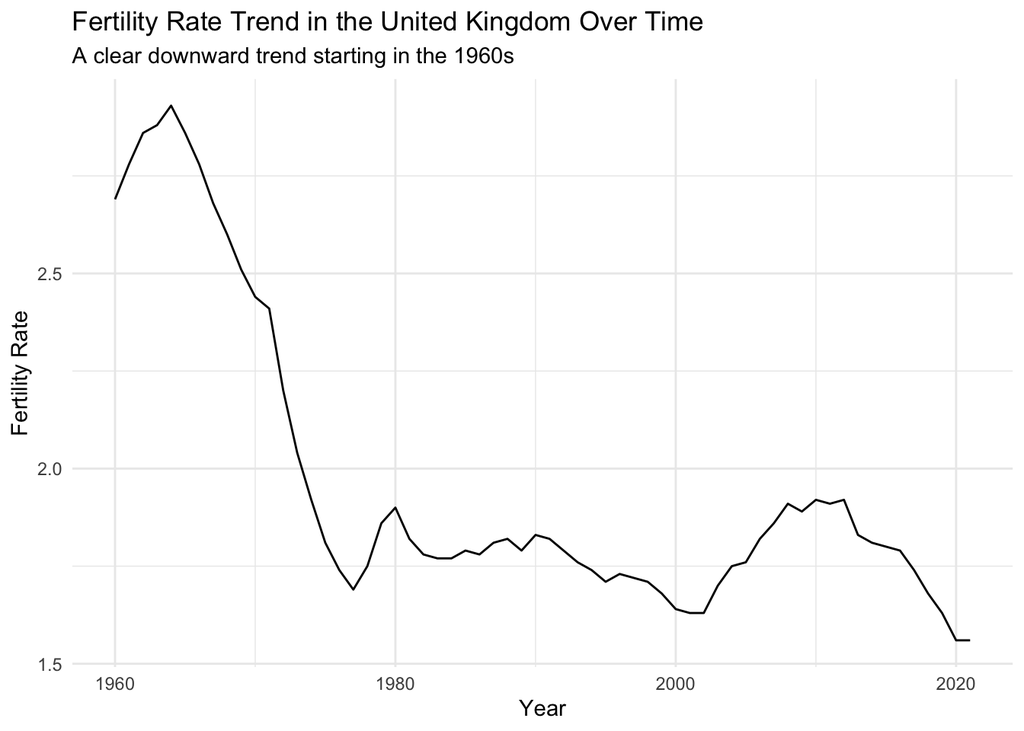

```r
# United Kingdom
UK <- df %>% filter(country == "United Kingdom")

ggplot(UK, aes(x = date, y = fertility_rate)) +
  geom_line() +
  labs(title = "Fertility Rate Trend in the United Kingdom Over Time",
       subtitle = "A clear downward trend starting in the 1960s",
       x = "Year",
       y = "Fertility Rate") +
  theme_minimal()
```

By looking at this graph we can see there’s a steep decline in fertility rates from the mid-1960s until the mid-1970s. This was primarily due to increased access to contraception, notably the contraceptive pill. This period also saw significant shifts in social attitudes, with a greater focus on women’s rights, feminism, and the importance of career and education for women, leading many to delay or reduce childbearing.

This overall downward trend in the UK’s fertility rate is consistent with trends in other developed nations and reflects the impact of socio-economic changes and technological advancements. These factors, coupled with the high cost of raising children in an advanced economy, resulted in the continued decrease in fertility rates seen in the graph.

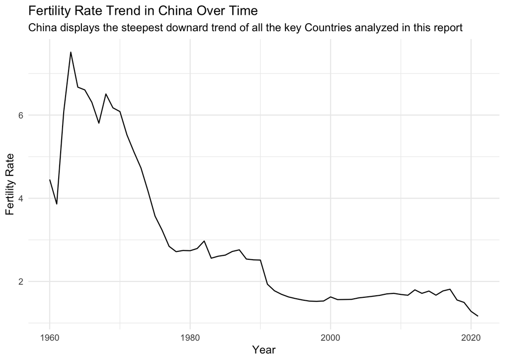

```r
# China
China <- df %>% filter(country == "China")

ggplot(China, aes(x = date, y = fertility_rate)) +
  geom_line() +
  labs(title = "Fertility Rate Trend in China Over Time",
       subtitle = "China displays the steepest downard trend of all the key Countries analyzed in this report",
       x = "Year",
       y = "Fertility Rate") +
  theme_minimal()
```

China initiated its stringent family planning policies in the early 1970s with a campaign named “Later, Long, Fewer”. Moreover, in 1980 China introduced the “One-Child Policy”, which was a population control measure to aimed to limit the country’s rapidly growing population. Therefore, it is likely that the extreme steepness of decline of its fertility rate was (at least partially) caused by such policies.

```r
#write.csv(df, file = "fertility_rates.csv", row.names = FALSE)
```

In the present era, a significant trend is taking place in many developed countries: the fertility rate has fallen below the replacement rate. The replacement rate, typically set at of 2.1 children per woman, is the level of fertility required for a population to maintain its size from one generation to the next.

A fertility rate below the replacement rate suggests that each generation is having fewer children than is required to keep the population stable. This trend can lead to a gradual decline in the population over time, as the number of births is insufficient to replace the number of individuals who pass away.

With fewer children being born, the population will tend to age as a larger proportion of people belong to older age groups. This can lead to demographic imbalances, with potential economic and healthcare implications. For instance, a reduced workforce can lead to challenges in funding social security systems, potentially impacting the financial stability of pension and retirement programs. A smaller workforce can lead to a reduction in the government tax revenue and thus, constrain the government’s ability to fund public services and infrastructure.

In response to population decline, immigration becomes a critical strategy for some countries. Well-designed immigration policies can play a crucial role by attracting newcomers to address labor shortages, maintaining economic growth, supporting social security systems, and fostering innovation.

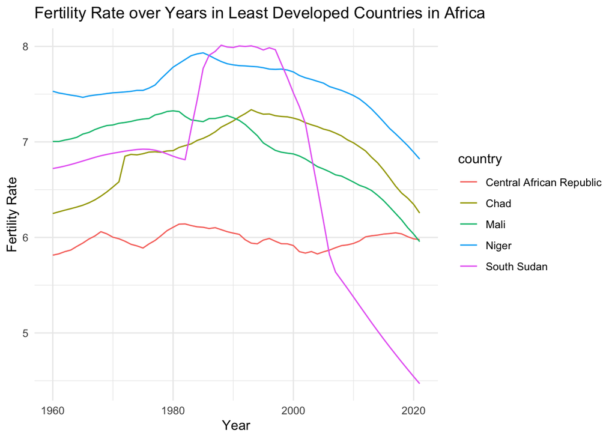

```r
# List of least developed countries in Africa
least_developed_countries <- c("Niger", "Central African Republic", "Chad",
                               "South Sudan", "Mali")

# Filter the dataset to include only the listed countries
filtered_data <- df %>% filter(country %in% least_developed_countries)

# Plotting the graph
ggplot(filtered_data, aes(x = date, y = fertility_rate, color = country)) +
  geom_line() +
  labs(title = "Fertility Rate over Years in Least Developed Countries in Africa",
       x = "Year",
       y = "Fertility Rate") +
  theme_minimal()
```

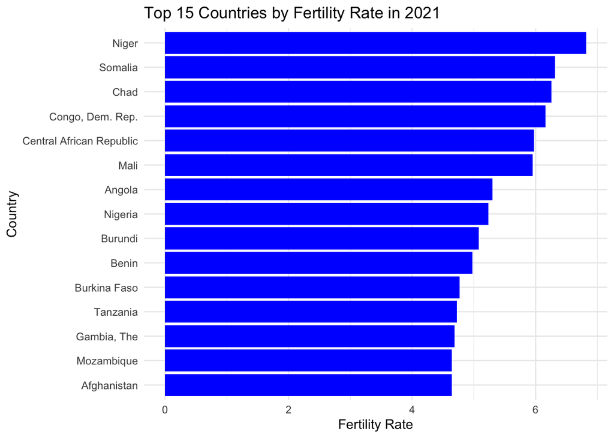

```r
# Prepare the data: Arrange by descending fertility rate and select the top 15 countries in 2021
top_countries <- df %>%
    filter(date == 2021) %>%
    arrange(desc(fertility_rate)) %>%
    head(15)

# Create the ordered bar chart using fct_reorder
ggplot(top_countries, aes(x = fct_reorder(country, fertility_rate), y = fertility_rate)) +
    geom_bar(stat = "identity", fill="blue") +
    coord_flip() +
    labs(title = "Top 15 Countries by Fertility Rate in 2021",
         x = "Country",
         y = "Fertility Rate") +
    theme_minimal()
```

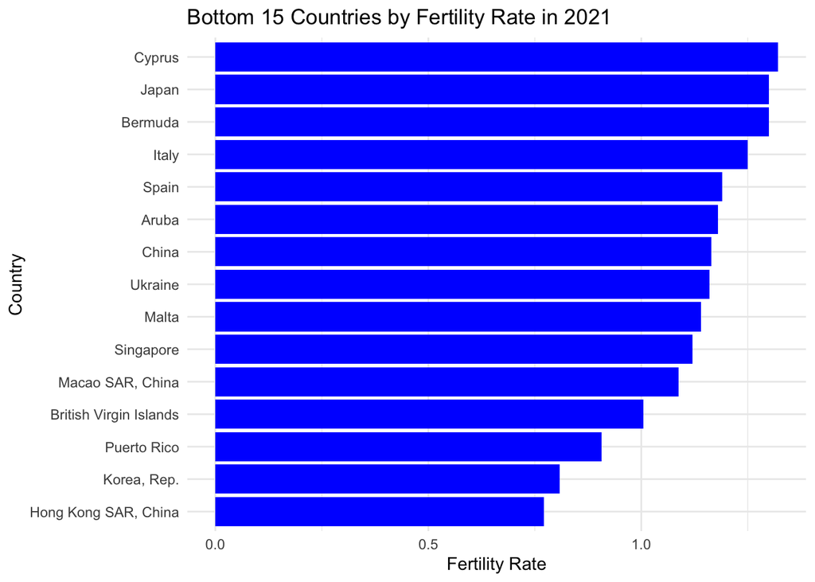

```r
bottom_countries <- df %>%
    filter(date == 2021) %>%
    arrange(fertility_rate) %>%
    head(15)

# Create the ordered bar chart using fct_reorder for the bottom 15 countries
ggplot(bottom_countries, aes(x = fct_reorder(country, fertility_rate), y = fertility_rate)) +
    geom_bar(stat = "identity", fill="blue") +
    coord_flip() +
    labs(title = "Bottom 15 Countries by Fertility Rate in 2021",
         x = "Country",
         y = "Fertility Rate") +
    theme_minimal()
```